# Pre-processing & Deriving Conditional League Strengths

## Data Overview

The following data was gathered using the `worldfootballR` library to scrape 2019-20 UEFA Champions League group stage and knockout game results and the 2018-19 domestic league results for the 32 competing teams across 16 individual league competitions[^1] from fbref.com.

## Data Pre-processing

In order to use the domestic competition and UEFA Champions League matchup data scraped from [fbref.com](https://www.fbref.com/)[^2] with the Bradley-Terry package, `BradleyTerry2`, the raw data must first be cleaned, parsed, and reformated into the package’s expected format. This code follows that found in Lecture 12 (Deshpande 2025), particularly when refactoring home and away win data into a trainable DataFrame.

```
# Helper to remove xG columns from relevant leagues so all competitions have the same number of columns
remove_xg = function(df){
  if((df %>% select(contains('_xG')) %>% length()) > 0){
    return(df %>% select(-contains('_xG')))
  }
  else {
    return(df)
  }
}
austria = remove_xg(austria)
belgium = remove_xg(belgium)
croatia = remove_xg(croatia)
czech = remove_xg(czech)
england = remove_xg(england)
france = remove_xg(france)
germany = remove_xg(germany)
greece = remove_xg(greece)
italy = remove_xg(italy)
nether = remove_xg(nether)
portugal = remove_xg(portugal)
russia = remove_xg(russia)
serbia = remove_xg(serbia)
spain = remove_xg(spain)
turkey = remove_xg(turkey)
ukraine = remove_xg(ukraine)
```

```
# Concatenate all leagues together
all = austria %>%
  rbind(belgium) %>%
  rbind(croatia) %>%
  rbind(czech) %>%
  rbind(england) %>%
  rbind(france) %>%
  rbind(germany) %>%
  rbind(greece) %>%
  rbind(italy) %>%
  rbind(nether) %>%
  rbind(portugal) %>%
  rbind(russia) %>%
  rbind(serbia) %>%
  rbind(spain) %>%
  rbind(turkey) %>%
  rbind(ukraine)
all %>% head(10)
```

| Competition_Name | Gender | Country | Season_End_Year | Round | Wk | Day | Date | Time | Home | HomeGoals | Away | AwayGoals | Attendance | Venue | Referee | Notes | MatchURL |
| --- | --- | --- | --- | --- | --- | --- | --- | --- | --- | --- | --- | --- | --- | --- | --- | --- | --- |
| Austrian Football Bundesliga | M | AUT | 2019 | Regular season | 1 | Fri | 2018-07-27 | 20:45:00 | Austria Wien | 2 | Wacker Innsbr | 1 | 12673 | Generali Arena | Christopher Jäger | NA | https://fbref.com/en/matches/6c36d5e8/Austria-Wien-Wacker-Innsbruck-July-27-2018-Austrian-Bundesliga |
| Austrian Football Bundesliga | M | AUT | 2019 | Regular season | 1 | Sat | 2018-07-28 | 17:00:00 | SCR Altach | 2 | Mattersburg | 3 | 4523 | CASHPOINT Arena | Dieter Muckenhammer | NA | https://fbref.com/en/matches/b5940ee5/Rheindorf-Altach-Mattersburg-July-28-2018-Austrian-Bundesliga |
| Austrian Football Bundesliga | M | AUT | 2019 | Regular season | 1 | Sat | 2018-07-28 | 17:00:00 | Sturm Graz | 3 | Hartberg | 2 | 10785 | Merkur Arena | Rene Eisner | NA | https://fbref.com/en/matches/f54b7835/Sturm-Graz-Hartberg-July-28-2018-Austrian-Bundesliga |
| Austrian Football Bundesliga | M | AUT | 2019 | Regular season | 1 | Sun | 2018-07-29 | 17:00:00 | St. Pölten | 4 | Wolfsberger AC | 3 | 2786 | NV Arena | Robert Schörgenhofer | NA | https://fbref.com/en/matches/44323758/St-Polten-Wolfsberger-AC-July-29-2018-Austrian-Bundesliga |
| Austrian Football Bundesliga | M | AUT | 2019 | Regular season | 1 | Sun | 2018-07-29 | 17:00:00 | Admira | 0 | Rapid Wien | 3 | 5200 | BSFZ-Arena | Alexander Harkam | NA | https://fbref.com/en/matches/9b206c50/Admira-Wacker-Modling-Rapid-Wien-July-29-2018-Austrian-Bundesliga |
| Austrian Football Bundesliga | M | AUT | 2019 | Regular season | 1 | Sun | 2018-07-29 | 17:00:00 | RB Salzburg | 3 | LASK | 1 | 11532 | Red Bull Arena | Harald Lechner | NA | https://fbref.com/en/matches/7704f43d/Red-Bull-Salzburg-LASK-July-29-2018-Austrian-Bundesliga |
| Austrian Football Bundesliga | M | AUT | 2019 | Relegation round | 1 | Sat | 2019-03-30 | 17:00:00 | Hartberg | 0 | Wacker Innsbr | 2 | 4635 | PROfertil ARENA | Stefan Ebner | NA | https://fbref.com/en/matches/ed31c559/Hartberg-Wacker-Innsbruck-March-30-2019-Austrian-Bundesliga |
| Austrian Football Bundesliga | M | AUT | 2019 | Relegation round | 1 | Sat | 2019-03-30 | 17:00:00 | SCR Altach | 2 | Mattersburg | 1 | 4048 | CASHPOINT Arena | Manuel Schüttengruber | NA | https://fbref.com/en/matches/9473e323/Rheindorf-Altach-Mattersburg-March-30-2019-Austrian-Bundesliga |
| Austrian Football Bundesliga | M | AUT | 2019 | Relegation round | 1 | Sat | 2019-03-30 | 17:00:00 | Rapid Wien | 3 | Admira | 0 | 11600 | Allianz Stadion | Rene Eisner | NA | https://fbref.com/en/matches/0cc0fe4a/Rapid-Wien-Admira-Wacker-Modling-March-30-2019-Austrian-Bundesliga |
| Austrian Football Bundesliga | M | AUT | 2019 | Championship round | 1 | Sun | 2019-03-31 | 14:30:00 | Sturm Graz | 0 | St. Pölten | 1 | 8567 | Merkur Arena | Dominik Ouschan | NA | https://fbref.com/en/matches/ea07224c/Sturm-Graz-St-Polten-March-31-2019-Austrian-Bundesliga |

With the leagues all concatenated together, we can check to see the distribution of the complete DataFrame’s members.

| Competition_Name | Gender | Country | Season_End_Year | Round | Wk | Day | Date | Time | Home | HomeGoals | Away | AwayGoals | Attendance | Venue | Referee | Notes | MatchURL |
| --- | --- | --- | --- | --- | --- | --- | --- | --- | --- | --- | --- | --- | --- | --- | --- | --- | --- |
| Süper Lig | M | TUR | 2019 | NA | 28 | Sun | 2019-04-14 | 16:00:00 | Yeni Mal'spor | 1 | Alanyaspor | 1 | NA | Yeni Malatya Stadyumu | Serkan Çınar | NA | https://fbref.com/en/matches/c132193e/Yeni-Malatyaspor-Alanyaspor-April-14-2019-Super-Lig |
| La Liga | M | ESP | 2019 | NA | 22 | Sun | 2019-02-03 | 12:00:00 | Villarreal | 2 | Espanyol | 2 | 15476 | Estadio de la Cerámica | Guillermo Cuadra | NA | https://fbref.com/en/matches/9172e3c8/Villarreal-Espanyol-February-3-2019-La-Liga |
| Ligue 1 | M | FRA | 2019 | Ligue 1 | 35 | Fri | 2019-05-03 | 20:45:00 | Strasbourg | 1 | Marseille | 1 | 25962 | Stade de la Meinau | Jérôme Miguelgorry | NA | https://fbref.com/en/matches/3149818a/Strasbourg-Marseille-May-3-2019-Ligue-1 |
| La Liga | M | ESP | 2019 | NA | 1 | Sat | 2018-08-18 | 18:15:00 | Celta Vigo | 1 | Espanyol | 1 | 16215 | Estadio de Balaídos | Santiago Jaime | NA | https://fbref.com/en/matches/a8d60ff6/Celta-Vigo-Espanyol-August-18-2018-La-Liga |
| Serbian SuperLiga | M | SRB | 2019 | Regular season | 13 | Sun | 2018-10-28 | 16:30:00 | Mačva Šabac | 0 | Red Star | 2 | 5000 | Stadion FK Mačva | Ilja Brdar | NA | https://fbref.com/en/matches/296ba160/Macva-Sabac-Red-Star-October-28-2018-Serbian-SuperLiga |
| Eredivisie | M | NED | 2019 | Eredivisie | 6 | Sat | 2018-09-22 | 18:30:00 | Fortuna Sittard | 4 | Willem II | 4 | 8537 | Fortuna Sittard Stadion | Allard Lindhout | NA | https://fbref.com/en/matches/41f2a6a6/Fortuna-Sittard-Willem-II-September-22-2018-Eredivisie |
| La Liga | M | ESP | 2019 | NA | 36 | Sat | 2019-05-04 | 13:00:00 | Levante | 4 | Rayo Vallecano | 1 | 19868 | Estadio Ciudad de Valencia | Daniel Ask | NA | https://fbref.com/en/matches/05f0ac3a/Levante-Rayo-Vallecano-May-4-2019-La-Liga |
| Primeira Liga | M | POR | 2019 | NA | 28 | Sun | 2019-04-07 | 15:00:00 | Vitória Setúbal | 1 | Marítimo | 0 | 2702 | Estádio do Bonfim | Manuel Oliveira | NA | https://fbref.com/en/matches/1f7bc799/Vitoria-Setubal-Maritimo-April-7-2019-Primeira-Liga |
| Serie A | M | ITA | 2019 | NA | 27 | Sun | 2019-03-10 | 15:00:00 | Sampdoria | 1 | Atalanta | 2 | 20896 | Stadio Comunale Luigi Ferraris | Michael Fabbri | NA | https://fbref.com/en/matches/38ee4d56/Sampdoria-Atalanta-March-10-2019-Serie-A |
| Ukrainian Premier League | M | UKR | 2019 | Regular season | 16 | Sun | 2018-11-25 | 19:30:00 | FC Oleksandriya | 2 | Dynamo Kyiv | 1 | 2478 | KSK Nika | Ihor Paskhal | NA | https://fbref.com/en/matches/bbe5bffb/FC-Oleksandriya-Dynamo-Kyiv-November-25-2018-Ukrainian-Premier-League |

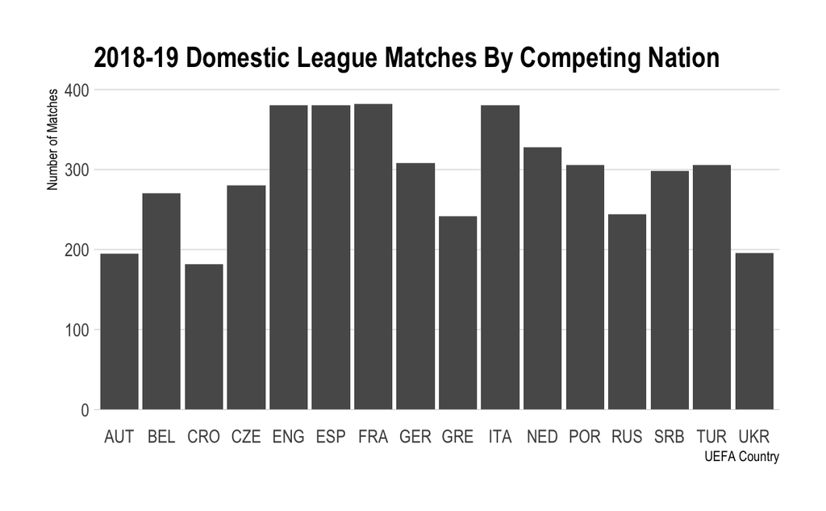

```
# CODE FROM LECTURE 12
# results <-
#  no_ties |>
#  dplyr::rename(home.team = Home, away.team = Opponent) |>
#  dplyr::group_by(home.team, away.team) |>
#  dplyr::summarise(
#    home.win = sum(Home_Winner),
#    away.win = sum(Opp_Winner), .groups = 'drop') |>
#  dplyr::mutate(
#    home.team = factor(home.team, levels = unik_teams),
#    away.team = factor(away.team,levels = unik_teams))
no_ties = all %>% filter(HomeGoals != AwayGoals) %>%
  filter(!str_detect(Round, "play-offs") | is.na(Round)) %>% ## removing matchups in pro/rel playoffs, otherwise we'll see skewed strengths for those leagues
  mutate(Home_Winner = case_when(HomeGoals > AwayGoals ~ 1, .default=0),
         Opp_Winner = case_when(AwayGoals > HomeGoals ~ 1, .default=0))

unik_teams = sort(unique(c(no_ties$Home, no_ties$Away)))

results = no_ties %>%
  rename(home.team = Home, away.team = Away) %>%
  group_by(home.team, away.team) %>%
  dplyr::summarise(
    home.win = sum(Home_Winner),
    away.win = sum(Opp_Winner), .groups = 'drop') |>
  dplyr::mutate(
    home.team = factor(home.team, levels = unik_teams),
    away.team = factor(away.team, levels = unik_teams))
results[sample(1:nrow(results),size=10),]
```

| home.team | away.team | home.win | away.win |
| --- | --- | --- | --- |
| Leverkusen | Bayern Munich | 1 | 0 |
| PSV Eindhoven | Vitesse | 1 | 0 |
| Real Sociedad | Villarreal | 0 | 1 |
| Partizan | Mladost Lučani | 1 | 0 |
| Nice | Dijon | 0 | 1 |
| Austria Wien | RB Salzburg | 0 | 2 |
| Benfica | Feirense | 1 | 0 |
| Real Madrid | Valladolid | 1 | 0 |
| Girona | Betis | 0 | 1 |
| Ural | Anzhi | 0 | 1 |

With the data now in place and formatted for `BradleyTerry2`, we can begin fitting a Bradley-Terry model to determine latent team strength for all clubs competing in the 2019-20 UEFA Champions League group stage based on their domestic league results.

## Fitting Bradley-Terry Model Based on Domestic League Results

For this problem, we’ll use the worst performing team in the lowest-rated domestic competition based on the UEFA association club coefficient[^3] for the 2018-19 season, which can be found at [UEFA.com](https://www.uefa.com/nationalassociations/uefarankings/country/?year=2019).

#### Table: 2018-19 UEFA association club coefficients for competing nations

```
read_csv('../data/raw/League_Participant_Info_2018-19.csv') %>%
  select(full_name, last_association_coef) %>%
  rename(Country = full_name, Coefficient = last_association_coef) %>%
  arrange(desc(Coefficient))
```

| Country | Coefficient |
| --- | --- |
| England | 22.642 |
| Spain | 19.571 |
| Germany | 15.214 |
| Italy | 12.642 |
| Portugal | 10.900 |
| France | 10.583 |
| Netherlands | 8.600 |
| Belgium | 7.800 |
| Russia | 7.583 |
| Czechia | 6.500 |

[output cut: 6 more lines]

```
fit <-
  BradleyTerry2::BTm(
    outcome = cbind(home.win, away.win),
    player1 = home.team, player2 = away.team,
    refcat = "Yenisey",
    data = results)
summary(fit)
```

```
Call:
BradleyTerry2::BTm(outcome = cbind(home.win, away.win), player1 = home.team,
    player2 = away.team, refcat = "Yenisey", data = results)

Coefficients: (15 not defined because of singularities)
                       Estimate Std. Error z value Pr(>|z|)
..Admira             -1.699e+00  7.224e-01  -2.351 0.018703 *
..ADO Den Haag        4.839e-01  5.791e-01   0.836 0.403390
..AEK Athens          1.817e+00  7.762e-01   2.341 0.019250 *
..Ajax                2.547e+00  7.054e-01   3.610 0.000306 ***
..Akhisarspor        -1.146e+00  6.298e-01  -1.820 0.068752 .
..Akhmat Grozny       1.802e+00  7.497e-01   2.404 0.016207 *
..Alanyaspor         -3.666e-01  5.764e-01  -0.636 0.524825
..Alavés              3.696e-01  5.777e-01   0.640 0.522352
..Almere City        -3.180e+01  2.058e+03  -0.015 0.987674
..Amiens             -5.772e-03  6.290e-01  -0.009 0.992678
..Anderlecht          7.644e-01  6.148e-01   1.243 0.213741
..Angers              6.001e-01  6.662e-01   0.901 0.367694
..Ankaragücü         -4.069e-01  5.677e-01  -0.717 0.473604
..Antalyaspor        -1.961e-01  5.593e-01  -0.351 0.725882
..Antwerp             9.371e-01  6.072e-01   1.543 0.122744
..Anzhi               2.166e-01  7.402e-01   0.293 0.769815
..Apollon Smyrnis    -1.927e+00  9.077e-01  -2.123 0.033748 *
..Aris                1.009e+00  7.079e-01   1.425 0.154217
..Arsenal             6.169e-01  5.923e-01   1.041 0.297644
..Arsenal Tula        2.234e+00  7.713e-01   2.896 0.003779 **
..Arsenal-Kyiv       -1.628e+00  6.876e-01  -2.368 0.017877 *
..Asteras Tripoli     2.133e-01  7.551e-01   0.283 0.777549
..Atalanta            1.094e+00  5.904e-01   1.853 0.063941 .
..Athletic Club       4.668e-01  5.969e-01   0.782 0.434186
..Atlético Madrid     1.678e+00  6.414e-01   2.616 0.008887 **
..Atromitos           1.573e+00  7.679e-01   2.048 0.040541 *
..Augsburg           -1.408e+00  6.414e-01  -2.196 0.028115 *
..Austria Wien       -5.992e-01  6.383e-01  -0.939 0.347870
..Aves                8.123e-02  6.295e-01   0.129 0.897329
..AZ Alkmaar          1.017e+00  6.115e-01   1.664 0.096204 .
..B-SAD               7.097e-01  7.094e-01   1.000 0.317148
..Bačka Palanka       7.686e-03  6.557e-01   0.012 0.990647
..Baník Ostrava      -1.863e+00  6.710e-01  -2.777 0.005491 **
..Barcelona           2.540e+00  7.526e-01   3.375 0.000737 ***
```

[output cut: 162 more lines]

```
..RB Salzburg         2.152e+00  8.667e-01   2.483 0.013033 *
..Real Madrid         9.388e-01  5.710e-01   1.644 0.100187
..Real Sociedad       4.991e-01  5.733e-01   0.871 0.383993
..Red Star            5.871e+00  1.375e+00   4.271 1.95e-05 ***
 [ reached 'max' / getOption("max.print") -- omitted 77 rows ]
---
Signif. codes:  0 ‘***’ 0.001 ‘**’ 0.01 ‘*’ 0.05 ‘.’ 0.1 ‘ ’ 1

(Dispersion parameter for binomial family taken to be 1)

    Null deviance: 4691.2  on 3323  degrees of freedom
Residual deviance: 3461.3  on 3061  degrees of freedom
AIC: 4069.8

Number of Fisher Scoring iterations: 14
```

```
lambda_hat = as.data.frame(BradleyTerry2::BTabilities(fit))
lambda_hat = lambda_hat %>% drop_na() %>% arrange(desc(ability))
lambda_hat = rownames_to_column(lambda_hat) %>% rename(team = rowname)
lambda_hat
```

| team | ability | s.e. |
| --- | --- | --- |
| PAOK | 16.865424258 | 246.2486803 |
| RKC Waalwijk | 15.172802609 | 1455.3976480 |
| NEC Nijmegen | 15.172802609 | 1455.3983351 |
| FC Kolos Kovalivka | 14.141751526 | 1455.3976976 |
| Red Star | 5.870847663 | 1.3746661 |
| Radnički Niš | 5.040786848 | 1.2521379 |
| Olympiacos | 3.768760706 | 1.1806422 |
| Dinamo Zagreb | 3.354133394 | 0.9317167 |
| Liverpool | 3.326899235 | 1.1183687 |
| Shakhtar | 3.308790803 | 1.1540573 |

[output cut: 253 more lines]

| Home | Country | ability | s.e. |
| --- | --- | --- | --- |
| Red Star | rs | 5.8708477 | 1.3746661 |
| Olympiacos | gr | 3.7687607 | 1.1806422 |
| Dinamo Zagreb | hr | 3.3541334 | 0.9317167 |
| Liverpool | eng | 3.3268992 | 1.1183687 |
| Shakhtar | ua | 3.3087908 | 1.1540573 |
| Benfica | pt | 3.1346783 | 0.8328164 |
| Zenit | ru | 2.8260211 | 0.7642741 |
| Loko Moscow | ru | 2.6627623 | 0.7726573 |
| Paris S-G | fr | 2.5871996 | 0.6797405 |
| Ajax | nl | 2.5466957 | 0.7054231 |

[output cut: 22 more lines]

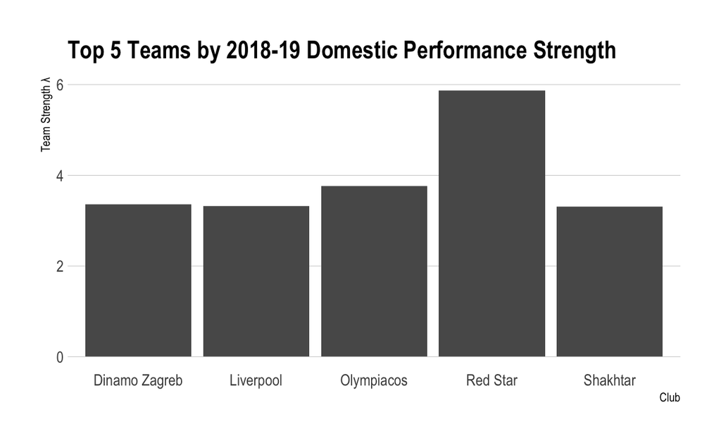

## References

Deshpande, Sameer. 2025. *Lecture 12: Bradley-Terry Models*. University of Wisconsin-Madison. https://skdeshpande91.github.io/stat479_fall2025/lectures/lecture12.html.

[^1]: Members from the following domestic leagues took part in the 2019-20 UEFA Champions League group stage: *Austrian Football Bundesliga, Belgian Pro League, Croatian Football League, Czech First League, English Premier League, French Ligue 1, German Fusball Bundesliga, Greek Super League, Italian Serie A, Dutch Eredivise, Portugese Premeira Liga, Russian Premier League, Serbian SuperLiga, Spanish La Liga, Turkish Super Lig, Ukrainian Premier League*
[^2]: Specific links and FBRef pages used can be found in the *GettingRawMatchupData.Rmd* notebook.
[^3]: https://en.wikipedia.org/wiki/UEFA_coefficient
[^4]: https://en.wikipedia.org/wiki/2018%E2%80%9319_Super_League_Greece#League_table